# STAT 184 Homework Exercises

DataComputing Chapters 7

Isha Thukral

## Assigned Exercises

- DC Chapter 7 Exercises: 7.1, 7.3, 7.5, 7.6, 7.7, and 7.8

## Front Matter

```r
# clean up workspace environment
rm(list = ls())

# all packages used for the assignment
library(mosaic)
library(tidyverse)
library(mosaicData)
library(esquisse)
library(dcData)
```

## Chapter 7 Exercises

### Problem 7.1

1. 3rd largest will be a reduction function
2. 3rd and 4th largest values are neither as there are no functions to find values together.
3. number of cases will be reduction function.
4. whether year would be a leap year is transformation
5. holiday finding will be neither as there in no holiday pattern.
6. range of a set is reduction function.
7. Transformation function is which day of the week.
8. This will be a reduction function.

### Problem 7.3

```r
Minneapolis2013 %>%
  summarise(count = n())
```

| count |
| --- |
| 80101 |

```r
Minneapolis2013 %>%
  group_by(Second) %>%
  tally(sort=TRUE)
```

| Second | n |
| --- | --- |
| BETSY HODGES | 14399 |
| DON SAMUELS | 14170 |
| MARK ANDREW | 12757 |
| undervote | 10598 |
| JACKIE CHERRYHOMES | 6470 |
| BOB FINE | 3751 |
| CAM WINTON | 3751 |
| DAN COHEN | 2283 |
| STEPHANIE WOODRUFF | 2128 |
| DOUG MANN | 1052 |

[output cut: 28 more lines]

```r
Minneapolis2013 %>%
  group_by(First) %>%
  summarise(total=n()) %>%
  filter(First=="undervote")
```

| First | total |
| --- | --- |
| undervote | 834 |

```r
Minneapolis2013 %>%
  group_by(Second) %>%
  summarise(total=n()) %>%
  filter(Second=="undervote")
```

| Second | total |
| --- | --- |
| undervote | 10598 |

```r
Minneapolis2013 %>%
  group_by(Third) %>%
  summarise(total=n()) %>%
  filter(Third=="undervote")
```

| Third | total |
| --- | --- |
| undervote | 19210 |

```r
Minneapolis2013 %>%
  group_by(First, Second) %>%
  tally(sort = TRUE)
```

| First | Second | n |
| --- | --- | --- |
| BETSY HODGES | MARK ANDREW | 8787 |
| BETSY HODGES | DON SAMUELS | 8743 |
| MARK ANDREW | BETSY HODGES | 6970 |
| MARK ANDREW | undervote | 3889 |
| DON SAMUELS | BETSY HODGES | 3346 |
| MARK ANDREW | DON SAMUELS | 2880 |
| BETSY HODGES | JACKIE CHERRYHOMES | 2563 |
| BETSY HODGES | undervote | 2238 |
| MARK ANDREW | JACKIE CHERRYHOMES | 2046 |
| DON SAMUELS | MARK ANDREW | 1424 |

[output cut: 990 more lines]

```r
Minneapolis2013 %>%
  group_by(Precinct) %>%
  tally(sort = TRUE)
```

| Precinct | n |
| --- | --- |
| P-06 | 9711 |
| P-02 | 9551 |
| P-08 | 9430 |
| P-03 | 8703 |
| P-05 | 8490 |
| P-07 | 8104 |
| P-04 | 7753 |
| P-01 | 7301 |
| P-09 | 5342 |
| P-10 | 1561 |

[output cut: 6 more lines]

### Problem 7.5

A. The result of VoterData_A dont seem to have any change and are grouped by first and last name. The case is the voters ballot.

B. VoterData_B shows the total number of cases in the Minneapolis while Minneapolis2013 has the entire data. The results is the same with 80101 cases in both. The case is the total cases.

C. The result of this table shows where they are ordered by first and second name and it shows the total for the grouping. First and second is cases.

D. The group_by() verb should always be followed by another verb like summarise. In this example there isn’t any hence an error appears

### Problem 7.6

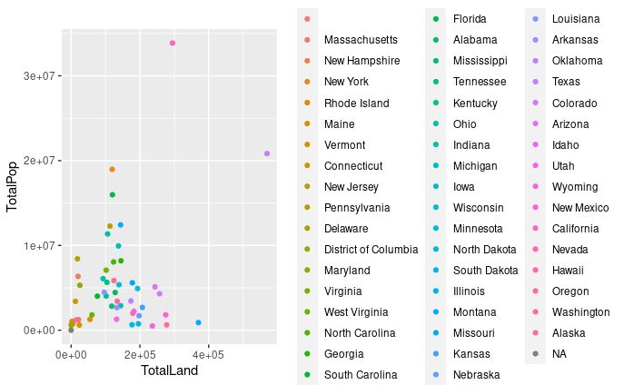

```r
TotalPopLand <-
  ZipGeography %>%
  group_by(State) %>%
  summarise(TotalPop = sum(Population, na.rm = TRUE), TotalLand = sum(LandArea, na.rm = TRUE))

ggplot(data = TotalPopLand, aes(x = TotalLand, y = TotalPop)) + geom_point()  + aes(colour = State) + theme(legend.position = "right") + labs(title = "")
```

```
Mapping API still under development and may change in future releases.
Warning in standardName(x, stateAlternatives, ignore.case = ignore.case,  :
  2 items were not translated
```

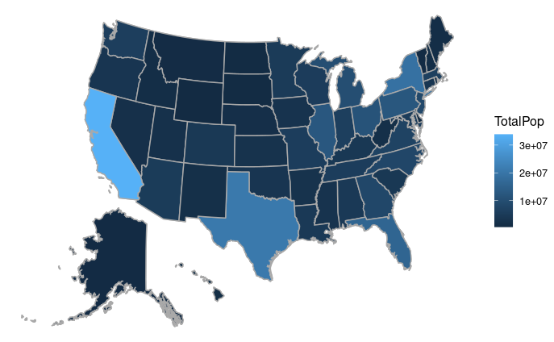

```r
TotalPopLand <-
  ZipGeography %>%
  group_by(State) %>%
  summarise(TotalPop = sum(Population, na.rm = TRUE), TotalLand = sum(LandArea, na.rm = TRUE))

mUSMap(TotalPopLand, key = "State", fill = "TotalPop")
```

```
Mapping API still under development and may change in future releases.
Warning in standardName(x, stateAlternatives, ignore.case = ignore.case,  :
  2 items were not translated
```

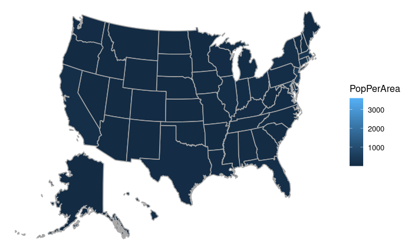

```r
TotalPopLand <-
  ZipGeography %>%
  group_by(State) %>%
  summarise(TotalPop = sum(Population, na.rm = TRUE), TotalLand = sum(LandArea, na.rm = TRUE), PopPerArea = TotalPop/TotalLand)

mUSMap(TotalPopLand, key = "State", fill = "PopPerArea")
```

### Problem 7.7

a.sex: sex, count, meanAge

b.diagnosis: diagnosis, count, meanAge

c.sex, diagnosis: sex, diagnosis, count, meanAge

d.age, diagnosis: age, diagnosis, count, meanAge

e.age: age, count, meanAge

### Problem 7.8

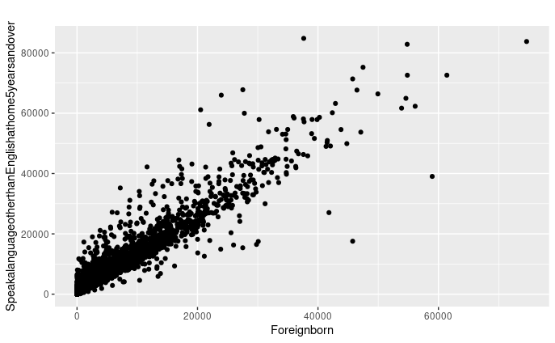

```r
ggplot(data = ZipDemography, aes(x = Foreignborn, y = SpeakalanguageotherthanEnglishathome5yearsandover)) + geom_point()  + labs(title = "")
```

The ZIP column exist but not states within the data. It includes the Bachelorsdegreeorhigher column but it would be very difficult to identify states based on just these columns.